# Confirmatory 1A Analysis Markdown

# PREPARATION

## First factor: Subfield

```
## # A tibble: 4 × 2
##   subfield_groups     n
##   <chr>           <int>
## 1 Cognition          91
## 2 Development        65
## 3 Other              75
## 4 Social             91
```

## Second factor: Time

```
## # A tibble: 3 × 2
##   time_period       n
##   <chr>         <int>
## 1 1st half 2014   183
## 2 1st half 2015    67
## 3 2nd half 2014    72
```

# DATA ANOVA Analysis

```
## Contrasts set to contr.sum for the following variables: time_period, subfield_groups
```

(#tab:unnamed-chunk-6)

*Between-subjects ANOVA for Open Data Scores*

| Effect | $F$ | $\mathit{df}_1$ | $\mathit{df}_2$ | $\mathit{MSE}$ | $p$ | $\hat{\eta}^2_G$ |
| --- | --- | --- | --- | --- | --- | --- |
| Time period | 11.29 | 2 | 310 | 41.51 | < .001 | .068 |
| Subfield groups | 2.23 | 3 | 310 | 41.51 | .085 | .021 |
| Time period $\times$ Subfield groups | 1.57 | 6 | 310 | 41.51 | .157 | .029 |

Our two-way between-subjects ANOVA generated a significant main effect of time period, $F(2, 310) = 11.29$, $\mathit{MSE} = 41.51$, $p < .001$, $\hat{\eta}^2_G = .068$. However, the main effect of subfield, $F(3, 310) = 2.23$, $\mathit{MSE} = 41.51$, $p = .085$, $\hat{\eta}^2_G = .021$, and the interaction between time period and subfield, $F(6, 310) = 1.57$, $\mathit{MSE} = 41.51$, $p = .157$, $\hat{\eta}^2_G = .029$, were not statistically significant.

# MATERIALS ANOVA Analysis

```
## Coefficient covariances computed by hccm()
```

```
## ANOVA Table (type II tests)
##
##                        Effect DFn DFd     F     p p<.05   ges
## 1             subfield_groups   3 310 4.033 0.008     * 0.038
## 2                 time_period   2 310 4.737 0.009     * 0.030
## 3 subfield_groups:time_period   6 310 0.853 0.530       0.016
```

Our two-way between-subjects ANOVA generated a significant main effect of subfield, F(3, 310) = 4.033, p = 0.008, ges = 0.038, and a significant main effect of time period, F(2, 310) = 4.737, p = 0.009, ges = 0.03. However, the interaction between subfield and time period, F(6, 310) = 0.853, p = 0.53, ges = 0.016, was not statistically significant.

```
## Contrasts set to contr.sum for the following variables: time_period, subfield_groups
```

```
## Anova Table (Type 2 tests)
##
## Response: total_materials_score
##                             num Df den Df    MSE      F      ges   Pr(>F)
## time_period                      2    310 32.158 4.7375 0.029658 0.009405 **
## subfield_groups                  3    310 32.158 4.0326 0.037559 0.007781 **
## time_period:subfield_groups      6    310 32.158 0.8526 0.016235 0.530212
## ---
## Signif. codes:  0 '***' 0.001 '**' 0.01 '*' 0.05 '.' 0.1 ' ' 1
```

(#tab:unnamed-chunk-8)

*Between-subjects ANOVA for Open Materials Scores*

| Effect | $F$ | $\mathit{df}_1$ | $\mathit{df}_2$ | $\mathit{MSE}$ | $p$ | $\hat{\eta}^2_G$ |
| --- | --- | --- | --- | --- | --- | --- |
| Time period | 4.74 | 2 | 310 | 32.16 | .009 | .030 |
| Subfield groups | 4.03 | 3 | 310 | 32.16 | .008 | .038 |
| Time period $\times$ Subfield groups | 0.85 | 6 | 310 | 32.16 | .530 | .016 |

*Note.* This table was created with apa_table().

Our two-way between-subjects ANOVA generated a significant main effect of subfield, $F(3, 310) = 4.03$, $\mathit{MSE} = 32.16$, $p = .008$, $\hat{\eta}^2_G = .038$, and a significant main effect of time period, $F(2, 310) = 4.74$, $\mathit{MSE} = 32.16$, $p = .009$, $\hat{\eta}^2_G = .030$. However the interaction between time period and subfield, $F(6, 310) = 0.85$, $\mathit{MSE} = 32.16$, $p = .530$, $\hat{\eta}^2_G = .016$, was not statistically significant.

# PLOTS

## DATA

### Subfield x Data Score

```
## # A tibble: 4 × 5
##   subfield_groups mean_data_score    SD     N stderr
##   <fct>                     <dbl> <dbl> <int>  <dbl>
## 1 Development                2.38  6.02    65  0.746
## 2 Social                     4.62  7.34    91  0.770
## 3 Cognition                  4.03  7.07    91  0.742
## 4 Other                      2.79  5.84    75  0.674
```

### Time Period x Data Score

```
## # A tibble: 3 × 5
##   time_period   mean_data_score    SD     N stderr
##   <fct>                   <dbl> <dbl> <int>  <dbl>
## 1 1st half 2014            2.14  5.24   183  0.388
## 2 2nd half 2014            4.90  7.47    72  0.880
## 3 1st half 2015            6.06  8.32    67  1.02
```

### Interaction between time and subfield - Data scores

```
## # A tibble: 12 × 6
## # Groups:   subfield_groups [4]
##    subfield_groups time_period   mean_data_score    SD     N stderr
##    <fct>           <fct>                   <dbl> <dbl> <int>  <dbl>
##  1 Development     1st half 2014           2.15   5.73    34  0.982
##  2 Development     2nd half 2014           3.31   6.78    16  1.69
##  3 Development     1st half 2015           1.93   6.13    15  1.58
##  4 Social          1st half 2014           2.27   4.69    52  0.650
##  5 Social          2nd half 2014           7.7    8.93    20  2.00
##  6 Social          1st half 2015           7.79   9.27    19  2.13
##  7 Cognition       1st half 2014           3.02   6.65    53  0.914
##  8 Cognition       2nd half 2014           4.11   6.60    19  1.51
##  9 Cognition       1st half 2015           6.79   8.23    19  1.89
## 10 Other           1st half 2014           0.932  3.03    44  0.457
## 11 Other           2nd half 2014           4      6.85    17  1.66
## 12 Other           1st half 2015           7.14   8.48    14  2.27
```

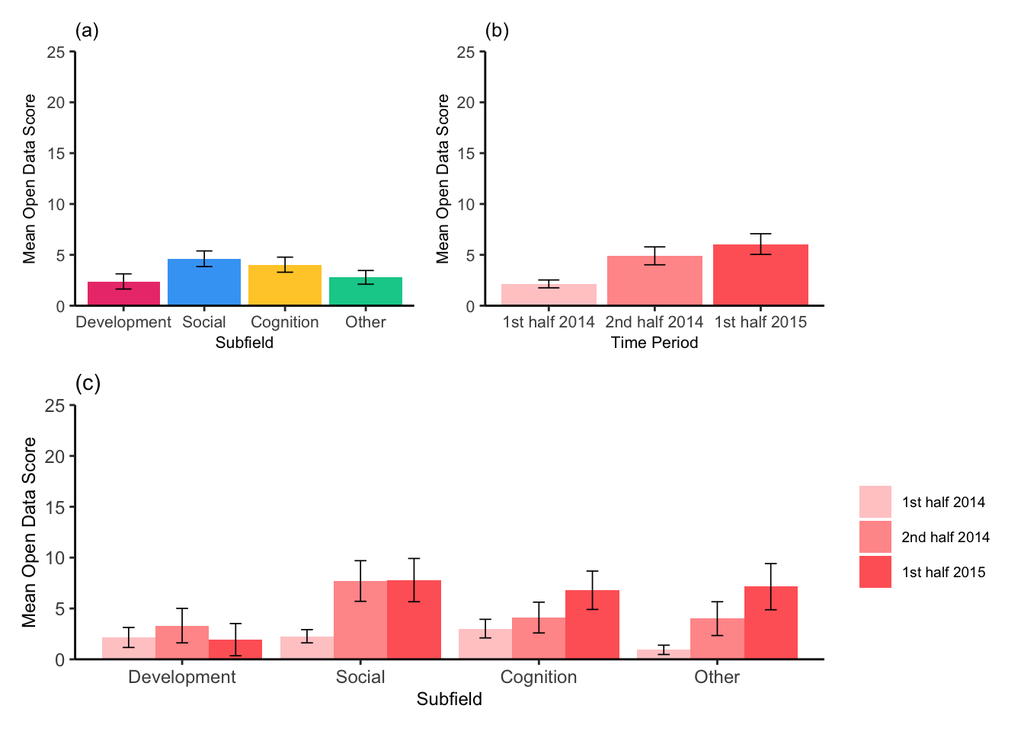

## MATERIALS

### Subfield x Materials Score

[output not shown]

### Time Period x Materials Score

```
## # A tibble: 3 × 5
##   time_period   mean_materials_score    SD     N stderr
##   <fct>                        <dbl> <dbl> <int>  <dbl>
## 1 1st half 2014                 2.73  5.04   183  0.373
## 2 2nd half 2014                 4.10  6.51    72  0.767
## 3 1st half 2015                 5     6.62    67  0.809
```

### Interaction between time and subfield - Materials Score

```
## # A tibble: 12 × 6
## # Groups:   subfield_groups [4]
##    subfield_groups time_period   mean_materials_score    SD     N stderr
##    <fct>           <fct>                        <dbl> <dbl> <int>  <dbl>
##  1 Development     1st half 2014                 1.44  4.31    34  0.740
##  2 Development     2nd half 2014                 1.38  3.91    16  0.978
##  3 Development     1st half 2015                 3.13  5.89    15  1.52
##  4 Social          1st half 2014                 2.77  4.63    52  0.643
##  5 Social          2nd half 2014                 6.9   8.00    20  1.79
##  6 Social          1st half 2015                 5.21  6.81    19  1.56
##  7 Cognition       1st half 2014                 3.94  5.97    53  0.820
##  8 Cognition       2nd half 2014                 4.26  5.96    19  1.37
##  9 Cognition       1st half 2015                 6.74  6.94    19  1.59
## 10 Other           1st half 2014                 2.20  4.61    44  0.695
## 11 Other           2nd half 2014                 3.18  6.28    17  1.52
## 12 Other           1st half 2015                 4.36  6.72    14  1.80
```

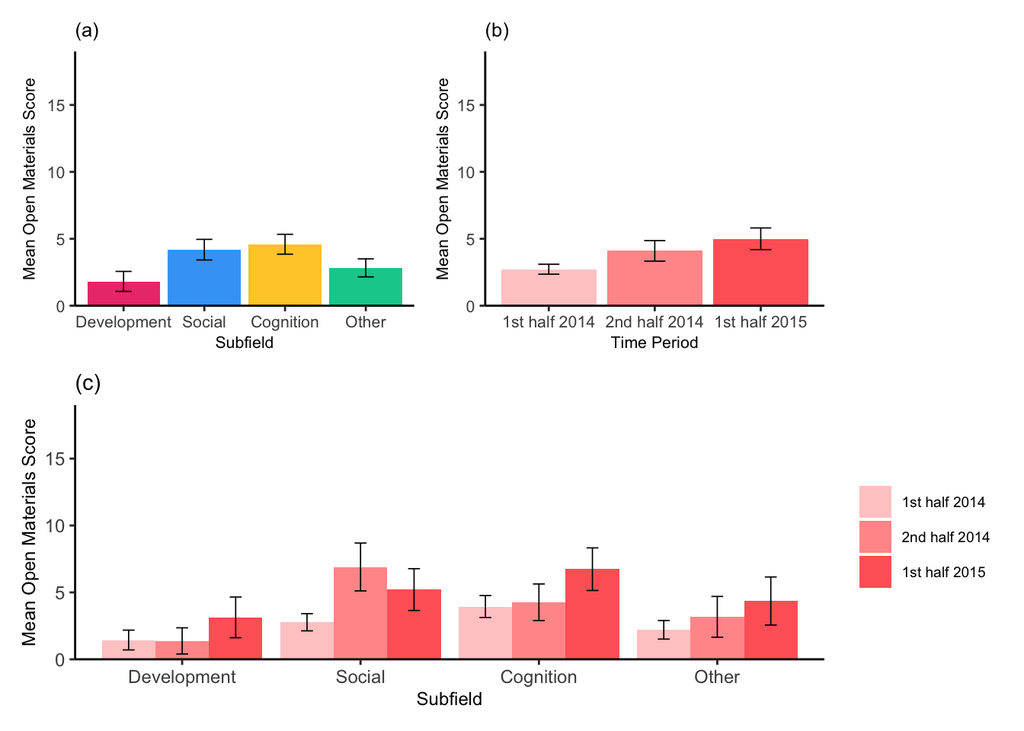

# SUBFIELD T-TESTS

## DATA

Subfield main effect for Open Data Scores was not significant, so no t-tests to run here

## MATERIALS

### Developmental vs. Cognition

[output not shown]

### Developmental vs. Social

[output not shown]

### Developmental vs. Other

[output not shown]

# TIME T-TESTS

## DATA

### First half 2014 vs. Second half 2014

[output not shown]

### Second half 2014 vs. First half 2015

[output not shown]

## MATERIALS

### First half 2014 vs. Second half 2014

[output not shown]

### Second half 2014 vs. First half 2015

[output not shown]

### First half 2014 vs. First half 2015

[output not shown]